# Case Study Unit #10: Imputations

By: Armando Vela & Jeff Washburn

Date: 11/3/2020

### Abstract

Machine learning models require a good dataset. Whenever a dataset has missing or impure data, then decisions need to be made on how to handle the dataset. Missing data can be categorized into 3 different types:

- Missing Completely at Random (MCAR)
  - Completely random missing data, cannot explain why
  - Example: Power outage causing various data to be missing
- Missing at Random (MAR)
  - Can find a pattern in which data is missing
  - Only missing in subset of data
  - Example: Car data - when make is Ford, data is missing
  - More common
- Missing Not at Random (MNAR)
  - You can tell definite pattern as why data is missing
  - Can 100% predict when data is missing
  - Example: Car data - when make is Ford, engine displacement is missing
  - Not very common

Once missing data is identified, then one must choose on how to handle that missing data. For example one could:

- Listwise Deletion: Drop the row if any missing data
- Pairwise Deletion: Say for example a case contains 3 variables: VAR1, VAR2, and VAR3. A case may have a missing value for VAR1, but this does not prevent some statistical procedures from using the same case to analyze variables VAR2 and VAR3
- Single Imputation: missing value is replaced by a value using for example: mean/median/mode, dummy variable, regression substition, hot deck imputation, last value carried forward
- Multiple Imputation: allow for the uncertainty about the missing data by creating several different plausible imputed data sets and appropriately combining results obtained from each of them

Lastly, once the strategy of handling missing data is executed, then use the data to create a model

### Introduction

Within this case study, we had to impute the missing values within the Sberbank Russian Housing Market dataset and run a machine learning model on the imputed dataframe. Additional information on how we identified missing values, dealt with anomolies, imputed NAs, and ran machine learning models can be found within the Methods section. Lastly, since our main focus for this study was imputations, we elected to use the 'pycaret' machine learning package to quickly run a large number of different regression algorithms on the same dataset.

A regression model was used to predict the housing prices for the Sberbank Russian Housing Market. Four dataframes were created each with different methods of imputations to address missing values. After running machine learning models on each, it was identified that the dataframe imputated using an interative Bayesian Ridge Regression approach provided the best R^2 score and Root Mean Squared Logarithmic Error (RMSLE) score.

### Methods

The approach we took on this dataset was as follows:

1. Identify the missing data (see Figure 1)
2. Impute values based on pattern of how data was missing (see Figure 2). The data appears to be MAR for certain groups of data. Because of this, we approached imputation by creating 4 different dataframes using different methodology for imputing the values using single and multiple imputation methods:
   - Simple Imputation using Mean:
     - Method: The mean is calculated for each column and the resulting amount replaces each NA value within the associated column. Note, the imputation is simple since it only goes through the data once.
   - Simple Imputation using Median:
     - Method: The median is calculated for each column and the resulting amount replaces each NA value within the associated column. Note, the imputation is simple since it only goes through the data once.
   - Iterative Imputation Using Bayesian Ridge Regression:
     - Method: The imputation is iterative since it passes over the data multiple times. For our instance, we used 5 iterations. Also, the initial strategy uses median values so that the Bayesian Ridge Regression can run through the model without errors.
   - Iterative Imputation using Decision Trees Regression:
     - Method: The imputation is iterative since it passes over the data multiple times. For our instance, we used 5 iterations. Also, the initial strategy uses median values so that the Decision Trees Regression can run through the model without errors.
3. Deal with anomalies. This includes handling outliers, and for example build years that do not fall in range.
4. Use pycaret to test a variety of models against each of the imputed data sets from step 2 above
5. Compare model performance to find best performing model against the imputed data sets.
6. Tune hyperparameters on best performing model found from step 5 above to improve model performance.

#### Identify Missing Values

```
Figure 1: Chart showing how much data is missing from each column
```

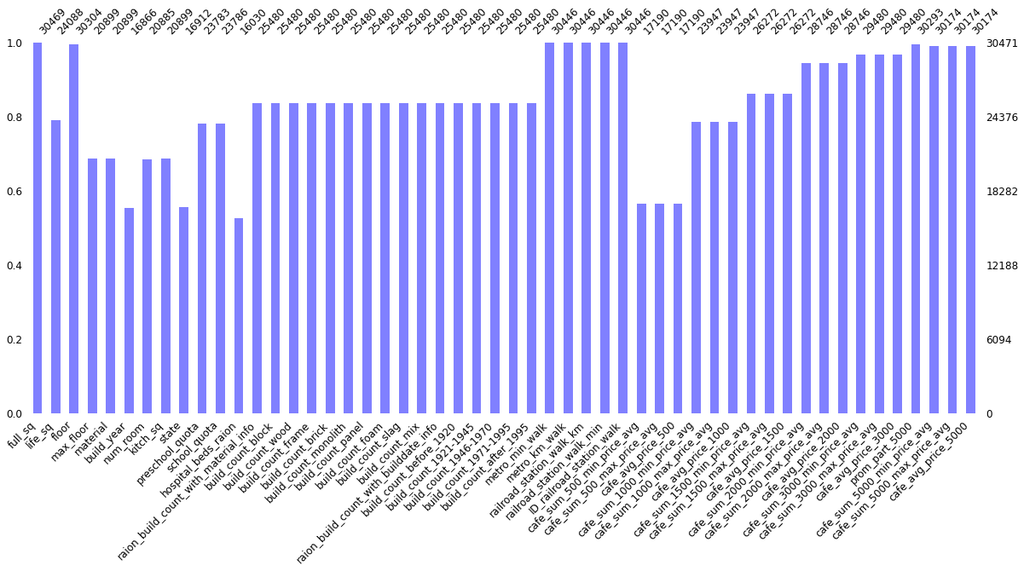

```python
# Look at each column that has missing values to get an idea of how much is missing
# Referencing code from: https://www.kaggle.com/viveksrinivasan/eda-focus-on-missing-values-and-simple-xgb
print("Figure 1: Chart showing how much data is missing from each column \n")
missingValueColumns = train.columns[train.isnull().any()].tolist()
msno.bar(train[missingValueColumns],\
            figsize=(20,8),color=(0.5, 0.5, 1),fontsize=12,labels=True,)
```

```
Figure 2: Chart showing where the data is missing in each observation
```

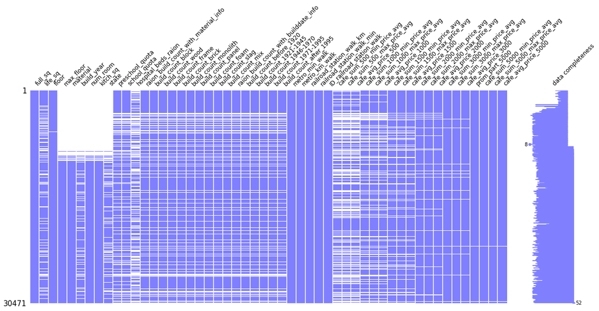

```python
# For each column that has missing data, show where it is missing in the data set
# Referencing code from: https://www.kaggle.com/viveksrinivasan/eda-focus-on-missing-values-and-simple-xgb
print("Figure 2: Chart showing where the data is missing in each observation \n")
msno.matrix(train[missingValueColumns],width_ratios=(10,1),\
            figsize=(20,8),color=(0.5, 0.5, 1),fontsize=12,sparkline=True,labels=True)
```

#### Anomaly Detection and Correction

##### Build_Year Corrections

As you will see in the table below, it looks like there were some anomolies within the build_year column of the data set. These were reviewed and corrected accordingly.

```
Figure 3: Box plot of build year - original data set
```

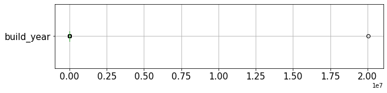

```python
print("Figure 3: Box plot of build year - original data set \n")
x= ['build_year']
bldOrig = df[x].boxplot(vert=False, figsize=(10,2), fontsize=15)
```

Figure 3 NOTES: As you can see, the boxplot has a large max at near 20Million which is skewing the variable tremendously.

```
Figure 4: Box plot of build year - corrected
```

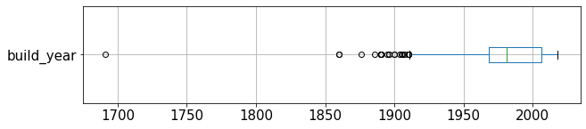

```python
print("Figure 4: Box plot of build year - corrected \n")
x= ['build_year']
bldClean = cleanDf[x].boxplot(vert=False, figsize=(10,2), fontsize=15)
```

Figure 4 NOTES: As you can see, the boxplot is now more in line with typical build year for houses.

##### Zero within Feature Corrections

The following features seemed odd to have a 0 within them. We made them NA so that they can be imputed by our methods.

- full_sq
- life_sq
- floor
- max_floor

```python
print("Figure 5: Table of associated features with 0's - original data set \n")
x= ['full_sq','life_sq','floor','max_floor']
df[x].describe()
```

```
Figure 5: Table of associated features with 0's - original data set
```

|  | full_sq | life_sq | floor | max_floor |
| --- | --- | --- | --- | --- |
| count | 30469.000000 | 24088.000000 | 30304.000000 | 20899.000000 |
| mean | 54.217828 | 34.403271 | 7.670803 | 12.558974 |
| std | 38.030199 | 52.285733 | 5.319989 | 6.756550 |
| min | 1.000000 | 0.000000 | 0.000000 | 0.000000 |
| 25% | 38.000000 | 20.000000 | 3.000000 | 9.000000 |
| 50% | 49.000000 | 30.000000 | 6.500000 | 12.000000 |
| 75% | 63.000000 | 43.000000 | 11.000000 | 17.000000 |
| max | 5326.000000 | 7478.000000 | 77.000000 | 117.000000 |

```python
print("Figure 6: Table of associated features with 0's - corrected \n")
x= ['full_sq','life_sq','floor','max_floor']
cleanDf[x].describe()
```

```
Figure 6: Table of associated features with 0's - corrected
```

|  | full_sq | life_sq | floor | max_floor |
| --- | --- | --- | --- | --- |
| count | 30469.000000 | 24043.000000 | 30295.000000 | 20349.000000 |
| mean | 54.217828 | 34.467662 | 7.673081 | 12.898423 |
| std | 38.030199 | 52.313434 | 5.319135 | 6.519689 |
| min | 1.000000 | 1.000000 | 1.000000 | 1.000000 |
| 25% | 38.000000 | 20.000000 | 3.000000 | 9.000000 |
| 50% | 49.000000 | 30.000000 | 7.000000 | 14.000000 |
| 75% | 63.000000 | 43.000000 | 11.000000 | 17.000000 |
| max | 5326.000000 | 7478.000000 | 77.000000 | 117.000000 |

#### Missing Values Imputations

Since such a large number of columns had NA values, we decided to experiment with using different imputation methods and compare results based on the R2 and RMSLE scores provided by our regression models. Also, since it looks like the items missing were missing at random and not missing completely at random, we felt deletion methods should not be used on this dataset.

With that said, we used the cleaned dataframe from above and imputed the missing values using the following imputation methods. Code details can be found within Appendix.

- Simple Imputation using Mean
- Simple Imputation using Median
- Iterative Imputation Using Bayesian Ridge Regression
- Iterative Imputation using Decision Trees Regression

#### Run Machine Learning Model

Once all missing values were imputed, we ran each dataframe using the pycaret module with the following techniques included:

- Normalization
- Feature Selection
- Remove MultiCollinearity

Additional code details can be found within the appendix below.

Figure 7: Example of PyCaret Output Displaying all Regression Models ran on iterative Bayesian Ridge Dataframe

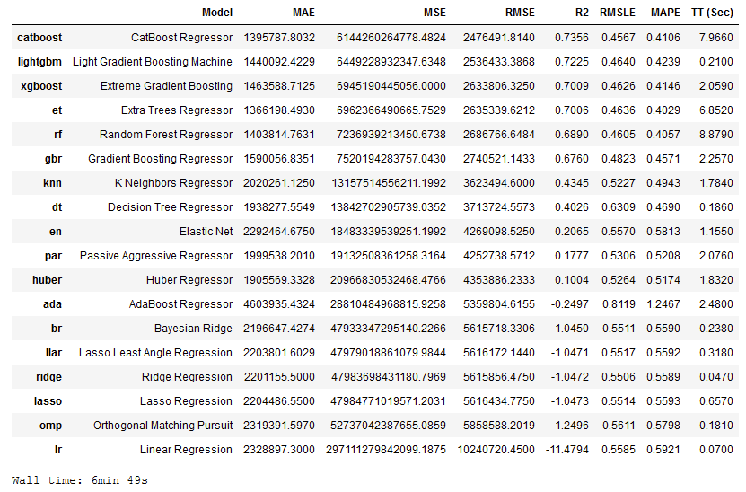

### Results

After running each dataframe using the pycaret machine learning module, we were able to identify that the Iterative Bayesisan Ridge (BR) imputated dataframe provided the best R2 and RMSLE scores. Furthermore, it was also identified that the catboost regressor algorithm provided the best regression scores for each of the dataframes.

See figure below displaying the scores for each model.

```python
print("Figure 8: Table of imputation methods and associated scores for best run regression model \n")
resultsDf
```

```
Figure 8: Table of imputation methods and associated scores for best run regression model
```

|  | DataFrame | Model | R2 | RMSLE |
| --- | --- | --- | --- | --- |
| 0 | simpleMeans | catboost_regresor | 0.6981 | 0.5699 |
| 1 | simpleMedian | catboost_regresor | 0.7015 | 0.4652 |
| 2 | iterativeBayesianRidge | catboost_regresor | 0.7356 | 0.4567 |
| 3 | iterativeDecisionTreeRegr | catboost_regresor | 0.6706 | 0.4701 |

Once we identified the Iterative BR model provided the best scores, we moved forward with tuning a few of the parameters within the algorithm. As you can see in the chart below, the Test R2 increased slightly.

Figure 9: Tuned Model Using Iterative BR Dataframe

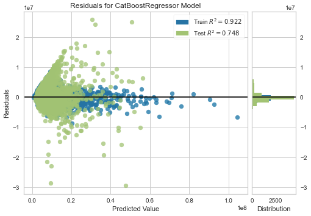

### Conclusion

As a result of this case study, we are confident in stating that how missing data is imputed can directly affect overall results. Furthermore, dropping NAs wouldnt have been a viable option since it would have eliminated more than two-thirds of the overall dataset. Finally, we can still improve the performance of our model by continuing to tune hyperparameters or conduct feature engineering within the dataset.

## Appendix: Code Details

#### Import necessary libraries and read in csv file

```python
#import the useful libraries.
import pandas as pd
import numpy as np
import seaborn as sns
from scipy import stats
import matplotlib.pyplot as plt
%matplotlib inline
from sklearn.model_selection import train_test_split

from sklearn.experimental import enable_iterative_imputer
from sklearn.impute import IterativeImputer
from sklearn.impute import SimpleImputer

from sklearn.linear_model import BayesianRidge
from sklearn.tree import DecisionTreeRegressor
from sklearn.ensemble import ExtraTreesRegressor
from sklearn.neighbors import KNeighborsRegressor

from pycaret.regression import *

# for charting missing values
import pylab
import calendar
import missingno as msno
from datetime import datetime
import warnings
pd.options.mode.chained_assignment = None
warnings.filterwarnings("ignore", category=DeprecationWarning)

# https://stackoverflow.com/questions/51325601/how-to-stop-my-pandas-data-table-from-being-truncated-when-printed
pd.set_option('display.max_rows', 500)
pd.set_option('display.max_columns', 500)
pd.set_option('display.width', 150)
```

#### Quick look at data structure

```python
df = pd.read_csv('train.csv')
```

```python
df.head()
```

|  | id | timestamp | full_sq | life_sq | floor | max_floor | material | build_year | num_room | kitch_sq | state | product_type | sub_area | area_m | raion_popul | green_zone_part | indust_part | children_preschool | preschool_quota | preschool_education_centers_raion | children_school | school_quota | school_education_centers_raion | school_education_centers_top_20_raion | hospital_beds_raion | healthcare_centers_raion | university_top_20_raion | sport_objects_raion | additional_education_raion | … |
| --- | --- | --- | --- | --- | --- | --- | --- | --- | --- | --- | --- | --- | --- | --- | --- | --- | --- | --- | --- | --- | --- | --- | --- | --- | --- | --- | --- | --- | --- | --- |
| 0 | 1 | 2011-08-20 | 43 | 27.0 | 4.0 | NaN | NaN | NaN | NaN | NaN | NaN | Investment | Bibirevo | 6.407578e+06 | 155572 | 0.189727 | 0.000070 | 9576 | 5001.0 | 5 | 10309 | 11065.0 | 5 | 0 | 240.0 | 1 | 0 | 7 | 3 | … |
| 1 | 2 | 2011-08-23 | 34 | 19.0 | 3.0 | NaN | NaN | NaN | NaN | NaN | NaN | Investment | Nagatinskij Zaton | 9.589337e+06 | 115352 | 0.372602 | 0.049637 | 6880 | 3119.0 | 5 | 7759 | 6237.0 | 8 | 0 | 229.0 | 1 | 0 | 6 | 1 | … |
| 2 | 3 | 2011-08-27 | 43 | 29.0 | 2.0 | NaN | NaN | NaN | NaN | NaN | NaN | Investment | Tekstil'shhiki | 4.808270e+06 | 101708 | 0.112560 | 0.118537 | 5879 | 1463.0 | 4 | 6207 | 5580.0 | 7 | 0 | 1183.0 | 1 | 0 | 5 | 1 | … |
| 3 | 4 | 2011-09-01 | 89 | 50.0 | 9.0 | NaN | NaN | NaN | NaN | NaN | NaN | Investment | Mitino | 1.258354e+07 | 178473 | 0.194703 | 0.069753 | 13087 | 6839.0 | 9 | 13670 | 17063.0 | 10 | 0 | NaN | 1 | 0 | 17 | 6 | … |
| 4 | 5 | 2011-09-05 | 77 | 77.0 | 4.0 | NaN | NaN | NaN | NaN | NaN | NaN | Investment | Basmannoe | 8.398461e+06 | 108171 | 0.015234 | 0.037316 | 5706 | 3240.0 | 7 | 6748 | 7770.0 | 9 | 0 | 562.0 | 4 | 2 | 25 | 2 | … |

```python
df.info()
```

```
<class 'pandas.core.frame.DataFrame'>
RangeIndex: 30471 entries, 0 to 30470
Columns: 292 entries, id to price_doc
dtypes: float64(119), int64(157), object(16)
memory usage: 67.9+ MB
```

### Get a quick understanding of independent variables that correlate with target variable ('price_doc')

```python
corr_matrix = df.corr()

corr_target = pd.DataFrame(corr_matrix['price_doc'])
corr_target['absCorrelation'] = abs(corr_target['price_doc'])

corr_target.sort_values(by='absCorrelation', ascending=False).head(n=15)
```

|  | price_doc | absCorrelation |
| --- | --- | --- |
| price_doc | 1.000000 | 1.000000 |
| num_room | 0.476337 | 0.476337 |
| full_sq | 0.341840 | 0.341840 |
| sport_count_5000 | 0.294864 | 0.294864 |
| sport_count_3000 | 0.290651 | 0.290651 |
| trc_count_5000 | 0.289371 | 0.289371 |
| zd_vokzaly_avto_km | -0.284069 | 0.284069 |
| sadovoe_km | -0.283622 | 0.283622 |
| kremlin_km | -0.279249 | 0.279249 |
| bulvar_ring_km | -0.279158 | 0.279158 |
| sport_count_2000 | 0.278056 | 0.278056 |
| ttk_km | -0.272620 | 0.272620 |
| office_sqm_5000 | 0.269977 | 0.269977 |
| trc_sqm_5000 | 0.268072 | 0.268072 |
| sport_count_1500 | 0.258376 | 0.258376 |

### Based on our initial correlation analysis, 'num_room' and 'full_sq' were the two most highly correlated features agains 'price_doc'. Lets review each feature to ensure there are no anomolies.

```python
corrFeats = ['full_sq', 'num_room']
df[corrFeats].describe()
```

|  | full_sq | num_room |
| --- | --- | --- |
| count | 30471.000000 | 20899.000000 |
| mean | 54.214269 | 1.909804 |
| std | 38.031487 | 0.851805 |
| min | 0.000000 | 0.000000 |
| 25% | 38.000000 | 1.000000 |
| 50% | 49.000000 | 2.000000 |
| 75% | 63.000000 | 2.000000 |
| max | 5326.000000 | 19.000000 |

Based on the table above, it looks like both features have 0 within each feature. Since 0 would not make sense for these features when buying/selling a home, they will be converted to nan.

```python
df['full_sq'] = df['full_sq'].replace([0],[np.nan])
df['num_room'] = df['num_room'].replace([0],[np.nan])
```

#### Create helpful functions

```python
def identifyNA(dataframe):
    """
    Purpose: To identify NA Count within each column of dataframe.
    Returns: A dataframe with column Title, NA Count, Total Count, and Ratio
    """
    retDf = pd.DataFrame(columns=['ColumnTitle', 'NA_Count', 'Total_Count', 'Ratio', 'VariableType'])
    columnList = dataframe.columns

    for idx in range(len(columnList)):
        column = columnList[idx]
        NA_Count = dataframe[column].isnull().sum()
        Total_Count = len(dataframe[column])
        Ratio = round(NA_Count / Total_Count, 2)
        VariableType = dataframe.dtypes[idx]

        retDf.loc[idx] = [column, NA_Count, Total_Count, Ratio, VariableType]

    return(retDf)
```

#### Identify Missing Data (NA) columns

Note: some of the eda for finding missing values referenced from Kaggle: https://www.kaggle.com/viveksrinivasan/eda-focus-on-missing-values-and-simple-xgb

##### Visualize Datatypes of Variables

```
  variableType  count
0        int64    156
1      float64    120
2       object     16
```

[output not shown]

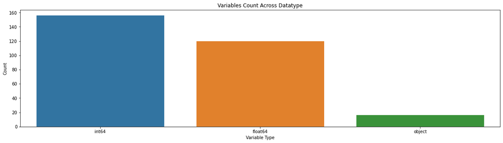

```python
# plotting produces Type Error
train=df
dataTypeDf = pd.DataFrame(train.dtypes.value_counts()).reset_index().rename(columns={"index":"variableType",0:"count"})
dataTypeDf

### copy value by value to newDf - plotting still produces Type Error
dataTypeDf2 = pd.DataFrame(columns=['variableType', 'count'])
dataTypeDf2 = dataTypeDf2.append({'variableType' : dataTypeDf.at[0,'variableType'] , 'count' : dataTypeDf.at[0,'count']} , ignore_index=True)
dataTypeDf2 = dataTypeDf2.append({'variableType' : dataTypeDf.at[1,'variableType'] , 'count' : dataTypeDf.at[1,'count']} , ignore_index=True)
dataTypeDf2 = dataTypeDf2.append({'variableType' : dataTypeDf.at[2,'variableType'] , 'count' : dataTypeDf.at[2,'count']} , ignore_index=True)

### hard code values
dataTypeDf3 = pd.DataFrame(columns=['variableType', 'count'])
dataTypeDf3 = dataTypeDf3.append({'variableType' : 'int64' , 'count' : dataTypeDf.at[0,'count']} , ignore_index=True)
dataTypeDf3 = dataTypeDf3.append({'variableType' : 'float64' , 'count' : dataTypeDf.at[1,'count']} , ignore_index=True)
dataTypeDf3 = dataTypeDf3.append({'variableType' : 'object' , 'count' : dataTypeDf.at[2,'count']} , ignore_index=True)


## copy columns to newDf - plotting still produces Type Error
selected_columns = dataTypeDf2[["variableType","count"]]
dataTypeDf4 = selected_columns.copy()

# Use the df that doesn't produce error
plotDf = dataTypeDf3
print(dataTypeDf)

# plot it
fig,ax = plt.subplots()
fig.set_size_inches(20,5)
sns.barplot(data=plotDf,x="variableType",y="count",ax=ax)
ax.set(xlabel='Variable Type', ylabel='Count',title="Variables Count Across Datatype")
```

##### Missing Value Analysis

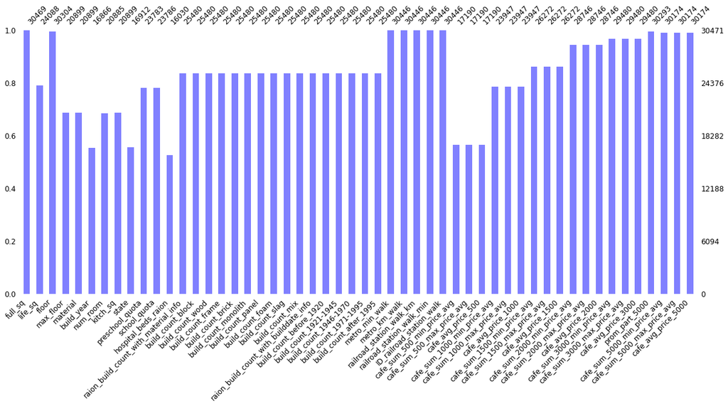

```python
missingValueColumns = train.columns[train.isnull().any()].tolist()
msno.bar(train[missingValueColumns],\
            figsize=(20,8),color=(0.5, 0.5, 1),fontsize=12,labels=True,)
```

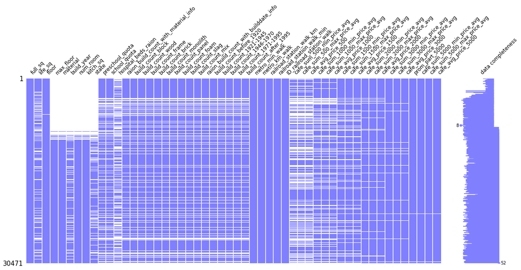

```python
msno.matrix(train[missingValueColumns],width_ratios=(10,1),\
            figsize=(20,8),color=(0.5, 0.5, 1),fontsize=12,sparkline=True,labels=True)
```

```python
dfofNAs = identifyNA(df)
dfofNAs = dfofNAs[dfofNAs['NA_Count'] > 0].sort_values(by='Ratio', ascending=True)
print(len(dfofNAs))
dfofNAs
```

```
52
```

|  | ColumnTitle | NA_Count | Total_Count | Ratio | VariableType |
| --- | --- | --- | --- | --- | --- |
| 2 | full_sq | 2 | 30471 | 0.00 | float64 |
| 99 | ID_railroad_station_walk | 25 | 30471 | 0.00 | float64 |
| 98 | railroad_station_walk_min | 25 | 30471 | 0.00 | float64 |
| 97 | railroad_station_walk_km | 25 | 30471 | 0.00 | float64 |
| 88 | metro_km_walk | 25 | 30471 | 0.00 | float64 |
| 87 | metro_min_walk | 25 | 30471 | 0.00 | float64 |
| 275 | cafe_sum_5000_min_price_avg | 297 | 30471 | 0.01 | float64 |
| 269 | prom_part_5000 | 178 | 30471 | 0.01 | float64 |
| 276 | cafe_sum_5000_max_price_avg | 297 | 30471 | 0.01 | float64 |
| 277 | cafe_avg_price_5000 | 297 | 30471 | 0.01 | float64 |
| 4 | floor | 167 | 30471 | 0.01 | float64 |
| 252 | cafe_sum_3000_min_price_avg | 991 | 30471 | 0.03 | float64 |
| 253 | cafe_sum_3000_max_price_avg | 991 | 30471 | 0.03 | float64 |
| 254 | cafe_avg_price_3000 | 991 | 30471 | 0.03 | float64 |
| 229 | cafe_sum_2000_min_price_avg | 1725 | 30471 | 0.06 | float64 |
| 230 | cafe_sum_2000_max_price_avg | 1725 | 30471 | 0.06 | float64 |
| 231 | cafe_avg_price_2000 | 1725 | 30471 | 0.06 | float64 |
| 206 | cafe_sum_1500_min_price_avg | 4199 | 30471 | 0.14 | float64 |
| 207 | cafe_sum_1500_max_price_avg | 4199 | 30471 | 0.14 | float64 |
| 208 | cafe_avg_price_1500 | 4199 | 30471 | 0.14 | float64 |
| 83 | build_count_after_1995 | 4991 | 30471 | 0.16 | float64 |
| 82 | build_count_1971-1995 | 4991 | 30471 | 0.16 | float64 |
| 79 | build_count_before_1920 | 4991 | 30471 | 0.16 | float64 |
| 81 | build_count_1946-1970 | 4991 | 30471 | 0.16 | float64 |
| 77 | build_count_mix | 4991 | 30471 | 0.16 | float64 |
| 76 | build_count_slag | 4991 | 30471 | 0.16 | float64 |
| 75 | build_count_foam | 4991 | 30471 | 0.16 | float64 |
| 74 | build_count_panel | 4991 | 30471 | 0.16 | float64 |
| 73 | build_count_monolith | 4991 | 30471 | 0.16 | float64 |
| 72 | build_count_brick | 4991 | 30471 | 0.16 | float64 |
| 71 | build_count_frame | 4991 | 30471 | 0.16 | float64 |
| 70 | build_count_wood | 4991 | 30471 | 0.16 | float64 |
| 69 | build_count_block | 4991 | 30471 | 0.16 | float64 |
| 68 | raion_build_count_with_material_info | 4991 | 30471 | 0.16 | float64 |
| 78 | raion_build_count_with_builddate_info | 4991 | 30471 | 0.16 | float64 |
| 80 | build_count_1921-1945 | 4991 | 30471 | 0.16 | float64 |
| 185 | cafe_avg_price_1000 | 6524 | 30471 | 0.21 | float64 |
| 3 | life_sq | 6383 | 30471 | 0.21 | float64 |
| 183 | cafe_sum_1000_min_price_avg | 6524 | 30471 | 0.21 | float64 |
| 184 | cafe_sum_1000_max_price_avg | 6524 | 30471 | 0.21 | float64 |
| 21 | school_quota | 6685 | 30471 | 0.22 | float64 |
| 18 | preschool_quota | 6688 | 30471 | 0.22 | float64 |
| 5 | max_floor | 9572 | 30471 | 0.31 | float64 |
| 6 | material | 9572 | 30471 | 0.31 | float64 |
| 8 | num_room | 9586 | 30471 | 0.31 | float64 |
| 9 | kitch_sq | 9572 | 30471 | 0.31 | float64 |
| 161 | cafe_sum_500_max_price_avg | 13281 | 30471 | 0.44 | float64 |
| 160 | cafe_sum_500_min_price_avg | 13281 | 30471 | 0.44 | float64 |
| 10 | state | 13559 | 30471 | 0.44 | float64 |
| 162 | cafe_avg_price_500 | 13281 | 30471 | 0.44 | float64 |
| 7 | build_year | 13605 | 30471 | 0.45 | float64 |
| 24 | hospital_beds_raion | 14441 | 30471 | 0.47 | float64 |

```python
naList = dfofNAs['ColumnTitle'].tolist()
```

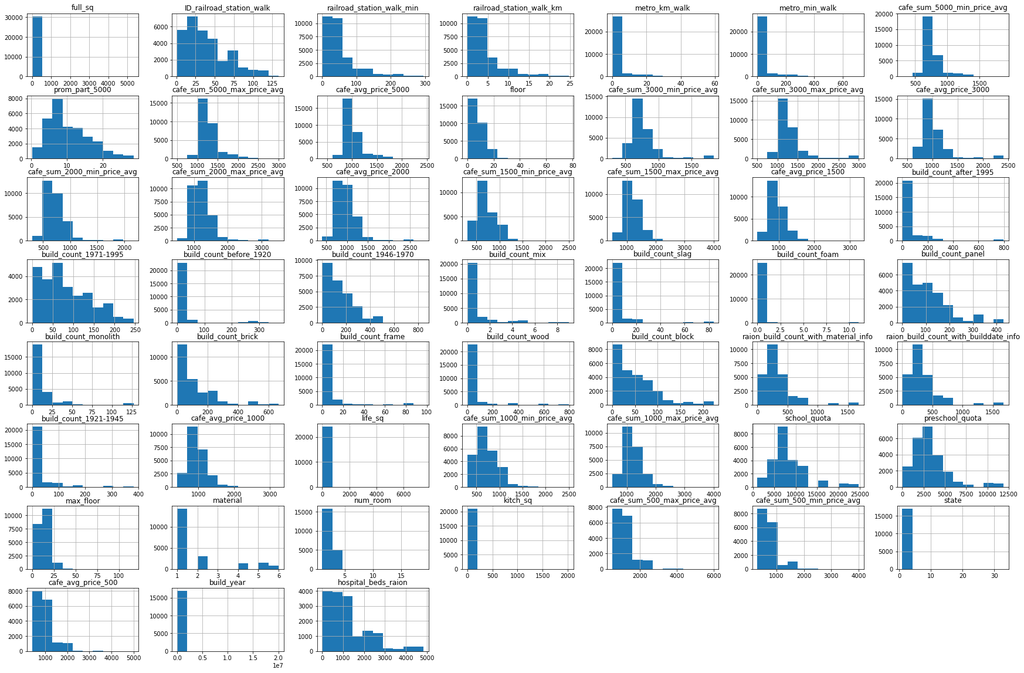

```python
df[naList].hist(figsize=(30,20))
plt.show()
```

### Based on the figure below, there seems to be an extreme outlier with build_year. We will review and address accordingly.

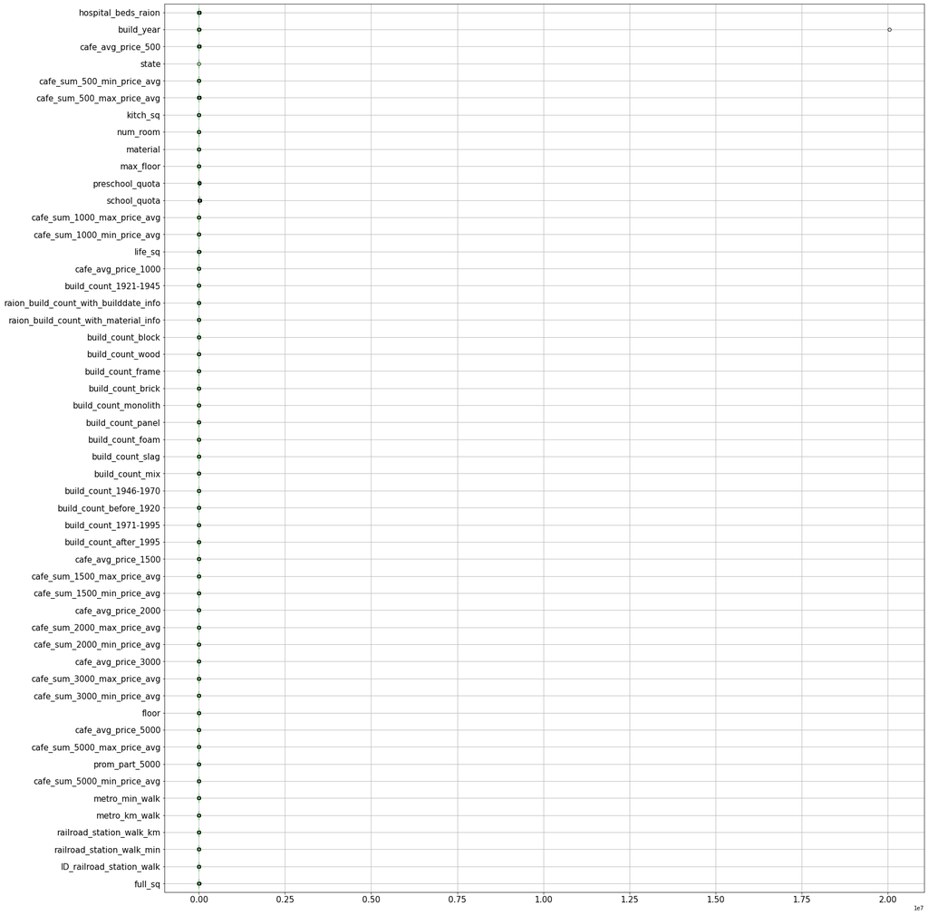

```python
df[naList].boxplot(vert=False, figsize=(25,30), fontsize=15)
```

```python
df[df['build_year'] > 2021]
```

|  | id | timestamp | full_sq | life_sq | floor | max_floor | material | build_year | num_room | kitch_sq | state | product_type | sub_area | area_m | raion_popul | green_zone_part | indust_part | children_preschool | preschool_quota | preschool_education_centers_raion | children_school | school_quota | school_education_centers_raion | school_education_centers_top_20_raion | hospital_beds_raion | healthcare_centers_raion | university_top_20_raion | sport_objects_raion | additional_education_raion | … |
| --- | --- | --- | --- | --- | --- | --- | --- | --- | --- | --- | --- | --- | --- | --- | --- | --- | --- | --- | --- | --- | --- | --- | --- | --- | --- | --- | --- | --- | --- | --- |
| 10089 | 10092 | 2013-08-27 | 37.0 | 16.0 | 8.0 | 12.0 | 1.0 | 20052009.0 | 1.0 | 9.0 | 33.0 | Investment | Cheremushki | 5467178.309 | 102618 | 0.055779 | 0.136330 | 5628 | 1944.0 | 4 | 6141 | 6887.0 | 5 | 0 | 262.0 | 3 | 0 | 6 | 4 | … |
| 15220 | 15223 | 2014-02-19 | 41.0 | 24.0 | 4.0 | 9.0 | 2.0 | 4965.0 | 2.0 | 5.0 | 3.0 | Investment | Sokolinaja Gora | 7905261.321 | 85956 | 0.014925 | 0.319809 | 4257 | 643.0 | 4 | 4756 | 5180.0 | 4 | 0 | 2857.0 | 5 | 1 | 14 | 4 | … |

Two cells within build_year are extreme outliers. We will create a new dataframe and clean up these values before imputations.

```python
#Create new dataframe so that the original df is not modified
cleanDf = df.copy()

cleanDf['build_year'] = cleanDf['build_year'].replace([20052009,4965],[2005,1965])
cleanDf[cleanDf['build_year'] > 2021]
```

|  | id | timestamp | full_sq | life_sq | floor | max_floor | material | build_year | num_room | kitch_sq | state | product_type | sub_area | area_m | raion_popul | green_zone_part | indust_part | children_preschool | preschool_quota | preschool_education_centers_raion | children_school | school_quota | school_education_centers_raion | school_education_centers_top_20_raion | hospital_beds_raion | healthcare_centers_raion | university_top_20_raion | sport_objects_raion | additional_education_raion | … |
| --- | --- | --- | --- | --- | --- | --- | --- | --- | --- | --- | --- | --- | --- | --- | --- | --- | --- | --- | --- | --- | --- | --- | --- | --- | --- | --- | --- | --- | --- | --- |

### Based on the image below we have corrected the large outliers for build_year. With that said, it looks like there are alot of build_year amounts hovering close to 0. These will need to be taken care of as well.

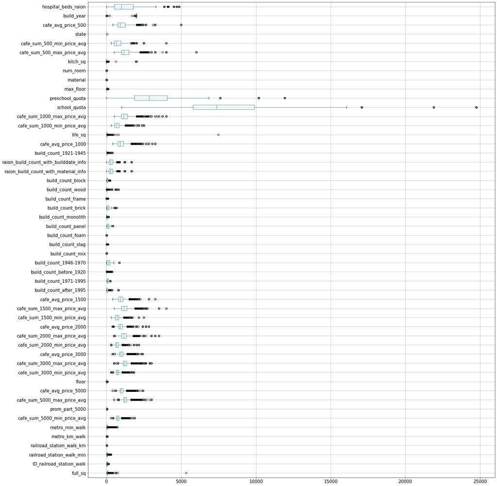

```python
cleanDf[naList].boxplot(vert=False, figsize=(25,30), fontsize=15)
```

```python
cleanDf[cleanDf['build_year'] < 250]
```

|  | id | timestamp | full_sq | life_sq | floor | max_floor | material | build_year | num_room | kitch_sq | state | product_type | sub_area | area_m | raion_popul | green_zone_part | indust_part | children_preschool | preschool_quota | preschool_education_centers_raion | children_school | school_quota | school_education_centers_raion | school_education_centers_top_20_raion | hospital_beds_raion | healthcare_centers_raion | university_top_20_raion | sport_objects_raion | additional_education_raion | … |
| --- | --- | --- | --- | --- | --- | --- | --- | --- | --- | --- | --- | --- | --- | --- | --- | --- | --- | --- | --- | --- | --- | --- | --- | --- | --- | --- | --- | --- | --- | --- |
| 9441 | 9444 | 2013-07-25 | 73.0 | 73.0 | 5.0 | 22.0 | 1.0 | 0.0 | 3.0 | 0.0 | NaN | OwnerOccupier | Poselenie Vnukovskoe | 2.553630e+07 | 4001 | 0.496315 | 0.007122 | 275 | NaN | 0 | 264 | NaN | 0 | 0 | NaN | 0 | 0 | 0 | 0 | … |
| 9620 | 9623 | 2013-08-05 | 65.0 | 35.0 | 7.0 | 12.0 | 1.0 | 1.0 | 2.0 | 1.0 | 1.0 | OwnerOccupier | Zapadnoe Degunino | 7.632940e+06 | 78810 | 0.051844 | 0.437885 | 5519 | 1503.0 | 3 | 5735 | 5782.0 | 3 | 0 | 1084.0 | 0 | 0 | 3 | 2 | … |
| 9700 | 9703 | 2013-08-08 | 60.0 | NaN | 24.0 | 24.0 | 1.0 | 1.0 | 2.0 | 1.0 | 1.0 | OwnerOccupier | Poselenie Vnukovskoe | 2.553630e+07 | 4001 | 0.496315 | 0.007122 | 275 | NaN | 0 | 264 | NaN | 0 | 0 | NaN | 0 | 0 | 0 | 0 | … |
| 9745 | 9748 | 2013-08-09 | 39.0 | 39.0 | 10.0 | 17.0 | 1.0 | 1.0 | 1.0 | 12.0 | 1.0 | OwnerOccupier | Nekrasovka | 1.139168e+07 | 19940 | 0.055644 | 0.243205 | 1706 | 2395.0 | 5 | 1564 | 7377.0 | 5 | 0 | 540.0 | 0 | 0 | 0 | 4 | … |
| 9764 | 9767 | 2013-08-12 | 119.0 | NaN | 24.0 | 1.0 | 1.0 | 1.0 | 1.0 | 1.0 | 1.0 | OwnerOccupier | Mitino | 1.258354e+07 | 178473 | 0.194703 | 0.069753 | 13087 | 6839.0 | 9 | 13670 | 17063.0 | 10 | 0 | NaN | 1 | 0 | 17 | 6 | … |
| ... | ... | ... | ... | ... | ... | ... | ... | ... | ... | ... | ... | ... | ... | ... | ... | ... | ... | ... | ... | ... | ... | ... | ... | ... | ... | ... | ... | ... | ... | … |
| 30394 | 30397 | 2015-06-24 | 52.0 | 52.0 | 14.0 | 17.0 | 1.0 | 1.0 | 2.0 | 1.0 | 1.0 | OwnerOccupier | Poselenie Vnukovskoe | 2.553630e+07 | 4001 | 0.496315 | 0.007122 | 275 | NaN | 0 | 264 | NaN | 0 | 0 | NaN | 0 | 0 | 0 | 0 | … |
| 30425 | 30428 | 2015-06-25 | 64.0 | NaN | 13.0 | 17.0 | 1.0 | 0.0 | 2.0 | 1.0 | 1.0 | OwnerOccupier | Solncevo | 1.132409e+07 | 113897 | 0.083810 | 0.371149 | 8340 | 3953.0 | 5 | 7065 | 9700.0 | 5 | 0 | 750.0 | 2 | 0 | 4 | 3 | … |
| 30429 | 30432 | 2015-06-26 | 42.0 | NaN | 7.0 | 17.0 | 6.0 | 0.0 | 1.0 | 1.0 | 1.0 | OwnerOccupier | Poselenie Vnukovskoe | 2.553630e+07 | 4001 | 0.496315 | 0.007122 | 275 | NaN | 0 | 264 | NaN | 0 | 0 | NaN | 0 | 0 | 0 | 0 | … |
| 30430 | 30433 | 2015-06-26 | 52.0 | NaN | 11.0 | 17.0 | 1.0 | 0.0 | 2.0 | 1.0 | 1.0 | OwnerOccupier | Poselenie Vnukovskoe | 2.553630e+07 | 4001 | 0.496315 | 0.007122 | 275 | NaN | 0 | 264 | NaN | 0 | 0 | NaN | 0 | 0 | 0 | 0 | … |
| 30451 | 30454 | 2015-06-29 | 37.0 | NaN | 3.0 | 3.0 | 1.0 | 0.0 | 1.0 | 1.0 | 1.0 | OwnerOccupier | Poselenie Novofedorovskoe | 1.487016e+08 | 6161 | 0.670840 | 0.005767 | 390 | NaN | 0 | 388 | NaN | 0 | 0 | NaN | 0 | 0 | 0 | 0 | … |

903 rows × 292 columns

Identify uniques values for years less than 250.

```python
cleanDf[cleanDf['build_year'] < 250]['build_year'].unique()
```

```
array([  0.,   1.,   3.,  20., 215.,  71.])
```

```python
cleanDf['build_year'] = cleanDf['build_year'].replace([0,1,3],[np.nan,np.nan,np.nan])
```

```python
cleanDf['build_year'] = cleanDf['build_year'].replace([20,215,71],[2000,2015,1970])
cleanDf[cleanDf['build_year'] <250]
```

|  | id | timestamp | full_sq | life_sq | floor | max_floor | material | build_year | num_room | kitch_sq | state | product_type | sub_area | area_m | raion_popul | green_zone_part | indust_part | children_preschool | preschool_quota | preschool_education_centers_raion | children_school | school_quota | school_education_centers_raion | school_education_centers_top_20_raion | hospital_beds_raion | healthcare_centers_raion | university_top_20_raion | sport_objects_raion | additional_education_raion | … |
| --- | --- | --- | --- | --- | --- | --- | --- | --- | --- | --- | --- | --- | --- | --- | --- | --- | --- | --- | --- | --- | --- | --- | --- | --- | --- | --- | --- | --- | --- | --- |

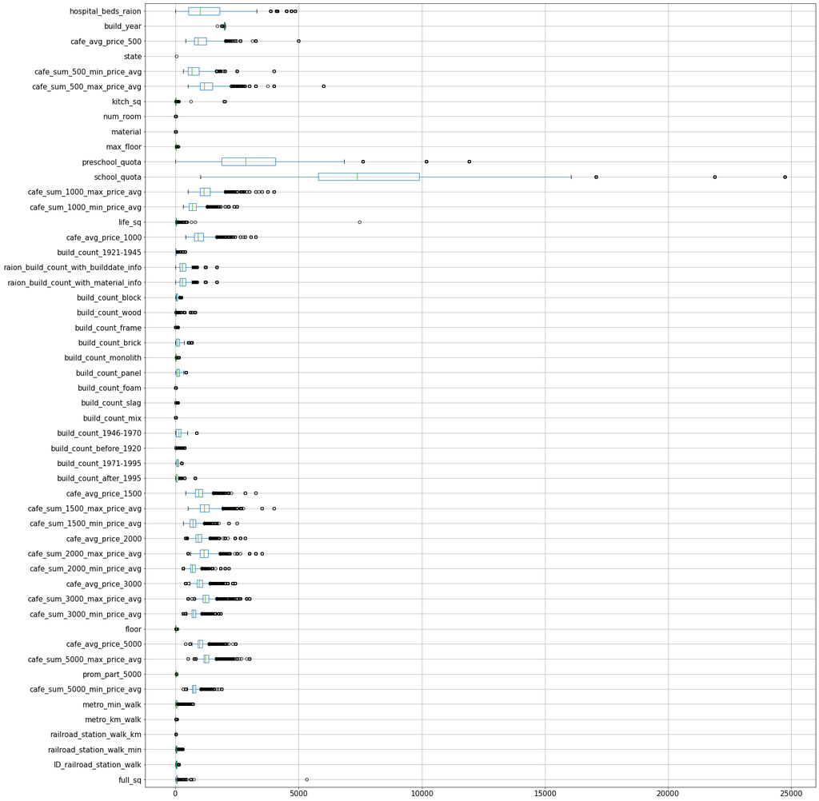

```python
cleanDf[naList].boxplot(vert=False, figsize=(25,30), fontsize=15)
```

### Other features within the boxplot above that seem odd to have a 0 within them. We will make them NA so that they can be imputed.

- full_sq
- life_sq
- floor
- max_floor

```python
cleanDf['full_sq'] = cleanDf['full_sq'].replace([0],[np.nan])
cleanDf['life_sq'] = cleanDf['life_sq'].replace([0],[np.nan])
cleanDf['floor'] = cleanDf['floor'].replace([0],[np.nan])
cleanDf['max_floor'] = cleanDf['max_floor'].replace([0],[np.nan])
```

### Iterative Imputer Example

### Since missing values are only within numeric columns. Filter for only numeric columns to impute.

```python
#Get entire dataset and filter for only numeric columns
df_Num = cleanDf.select_dtypes(include=[np.number])
df_cat = cleanDf.select_dtypes(exclude=[np.number])
```

```python
def imputeNA(dataframe, complexity, method):
    """
    Purpose: To impute NAs within each column of dataframe.
    Complexity: Simple or Iterative
    Methods for Simple Complexity: 'mean', 'median', 'most_frequent', 'constant'
    Methods for Iterative Complexity: BR, DTR, ETR, KNR
    Returns: A dataframe
    """

    if (complexity == 'Simple'):

        si = SimpleImputer(missing_values=np.nan, strategy=method)
        retDf = si.fit_transform(dataframe)

    elif (complexity == 'Iterative'):

        if (method == 'DTR'):
            impute_estimator = DecisionTreeRegressor(max_features='sqrt', random_state=0)
        elif (method == 'ETR'):
            impute_estimator = ExtraTreesRegressor(n_estimators=10, random_state=0)
        elif (method == 'KNR'):
            impute_estimator = KNeighborsRegressor(n_neighbors=15)
        elif (method == 'BR'):
            impute_estimator = BayesianRidge()


        imputer = IterativeImputer(estimator=impute_estimator,
                                   missing_values = np.nan,
                                   max_iter=5,
                                   random_state=0,
                                   verbose=0,
                                   initial_strategy='median')
        retDf = imputer.fit_transform(dataframe)

    columnNames = list(dataframe)
    retDf = pd.DataFrame(retDf, columns=columnNames)
    return(retDf)
```

## Create dataframes for comparison each with different imputation methods

```python
%%time
simpleMeans = imputeNA(df_Num, 'Simple', 'mean')
print(sum(identifyNA(simpleMeans)['Ratio']))
simpleMeans.to_csv('simpleMeans.csv')
print('FileSaved')
print('simpleMeans Done')
```

```
0.0
FileSaved
simpleMeans Done
Wall time: 7.25 s
```

```python
%%time
simpleMedian = imputeNA(df_Num, 'Simple', 'median')
print(sum(identifyNA(simpleMedian)['Ratio']))
simpleMedian.to_csv('simpleMedian.csv')
print('FileSaved')
print('simpleMedian Done')
```

```
0.0
FileSaved
simpleMedian Done
Wall time: 7.68 s
```

```python
%%time
iterativeBR = imputeNA(df_Num, 'Iterative', 'BR')
print(sum(identifyNA(iterativeBR)['Ratio']))
iterativeBR.to_csv('iterativeBR.csv')
print('FileSaved')
print('iterativeBR Done')
```

```
0.0
FileSaved
iterativeBR Done
Wall time: 2min 58s
```

```python
%%time
iterativeDTR = imputeNA(df_Num, 'Iterative', 'DTR')
print(sum(identifyNA(iterativeDTR)['Ratio']))
iterativeDTR.to_csv('iterativeDTR.csv')
print('FileSaved')
print('iterativeDTR Done')
```

```
0.0
FileSaved
iterativeDTR Done
Wall time: 2min 25s
```

# Save dataframes for use later so that we dont have to run the extensive code above

### Load saved dataframes

```python
simpleMeans = pd.read_csv('simpleMeans.csv')
simpleMedian = pd.read_csv('simpleMedian.csv')
iterativeBR = pd.read_csv('iterativeBR.csv')
iterativeDTR = pd.read_csv('iterativeDTR.csv')
```

```python
simpleMeans['file_name'] = 'simpleMeans'
simpleMedian['file_name'] = 'simpleMedian'
iterativeBR['file_name'] = 'iterativeBR'
iterativeDTR['file_name'] = 'iterativeDTR'

comparisonDf = pd.concat([simpleMeans, simpleMedian, iterativeBR,iterativeDTR])

comparisonDf.head()
```

|  | Unnamed: 0 | id | full_sq | life_sq | floor | max_floor | material | build_year | num_room | kitch_sq | ... | cafe_count_5000_price_4000 | cafe_count_5000_price_high | big_church_count_5000 | church_count_5000 | mosque_count_5000 | leisure_count_5000 | sport_count_5000 | market_count_5000 | price_doc | file_name |
| --- | --- | --- | --- | --- | --- | --- | --- | --- | --- | --- | --- | --- | --- | --- | --- | --- | --- | --- | --- | --- | --- |
| 0 | 0 | 1.0 | 43.0 | 27.0 | 4.0 | 12.898423 | 1.827121 | 1985.353376 | 1.911085 | 6.399301 | ... | 4.0 | 0.0 | 13.0 | 22.0 | 1.0 | 0.0 | 52.0 | 4.0 | 5850000.0 | simpleMeans |
| 1 | 1 | 2.0 | 34.0 | 19.0 | 3.0 | 12.898423 | 1.827121 | 1985.353376 | 1.911085 | 6.399301 | ... | 3.0 | 0.0 | 15.0 | 29.0 | 1.0 | 10.0 | 66.0 | 14.0 | 6000000.0 | simpleMeans |
| 2 | 2 | 3.0 | 43.0 | 29.0 | 2.0 | 12.898423 | 1.827121 | 1985.353376 | 1.911085 | 6.399301 | ... | 3.0 | 0.0 | 11.0 | 27.0 | 0.0 | 4.0 | 67.0 | 10.0 | 5700000.0 | simpleMeans |
| 3 | 3 | 4.0 | 89.0 | 50.0 | 9.0 | 12.898423 | 1.827121 | 1985.353376 | 1.911085 | 6.399301 | ... | 2.0 | 1.0 | 4.0 | 4.0 | 0.0 | 0.0 | 26.0 | 3.0 | 13100000.0 | simpleMeans |
| 4 | 4 | 5.0 | 77.0 | 77.0 | 4.0 | 12.898423 | 1.827121 | 1985.353376 | 1.911085 | 6.399301 | ... | 108.0 | 17.0 | 135.0 | 236.0 | 2.0 | 91.0 | 195.0 | 14.0 | 16331452.0 | simpleMeans |

5 rows × 278 columns

[output not shown]

[output not shown]

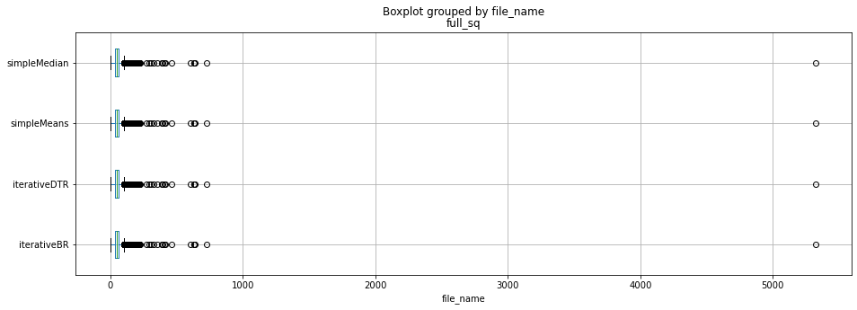

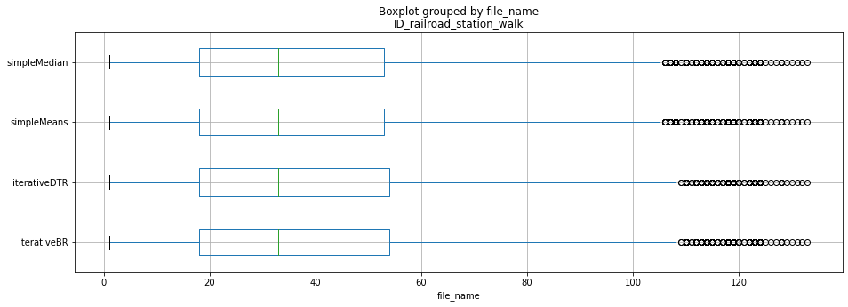

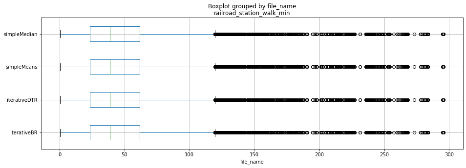

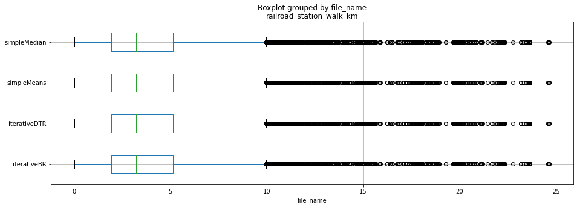

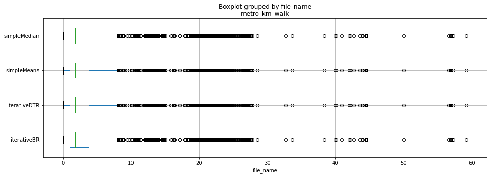

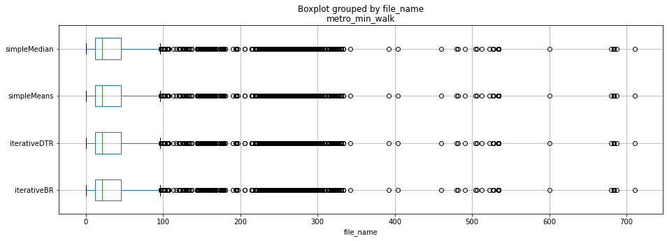

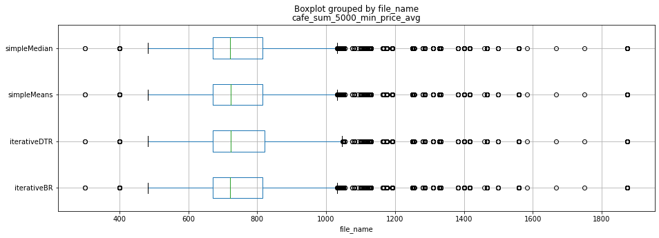

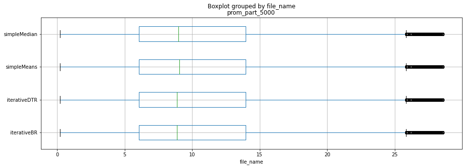

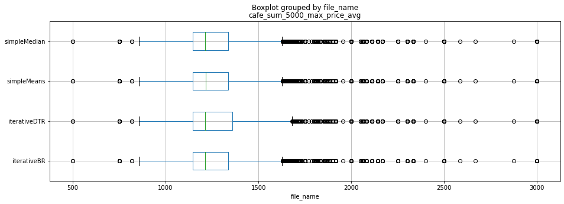

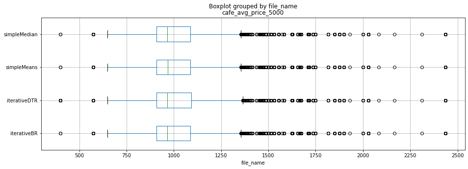

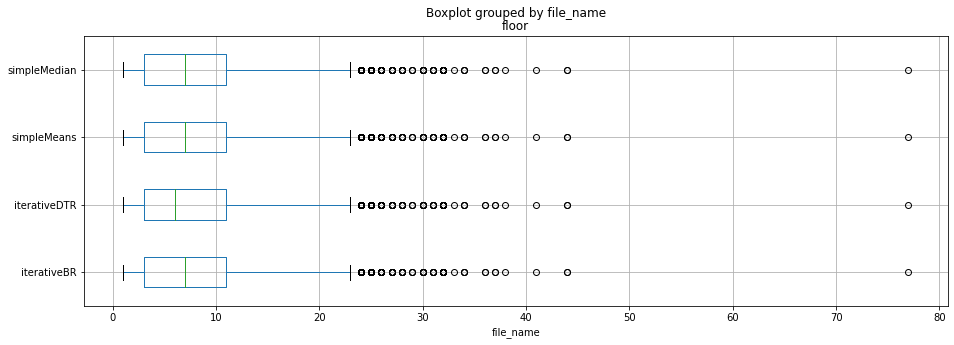

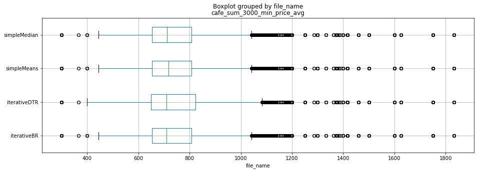

[40 more figures not shown]

```python
for i in naList:
    pic = comparisonDf.boxplot(column = i, by='file_name', vert=False, figsize=(15,5))
    print(pic)
```

## AutoML regression model below

```python
# combine imputated numerical dataframe with categorical dataframe
simpleMeans_clean = pd.concat([simpleMeans, df_cat], axis=1)
simpleMedian_clean = pd.concat([simpleMedian, df_cat], axis=1)
iterativeBR_clean = pd.concat([iterativeBR, df_cat], axis=1)
iterativeDTR_clean = pd.concat([iterativeDTR, df_cat], axis=1)

# get list of categorical dataframe
categorical = list(df_cat.columns)
categorical.remove('timestamp')
categorical
```

```
['product_type',
 'sub_area',
 'culture_objects_top_25',
 'thermal_power_plant_raion',
 'incineration_raion',
 'oil_chemistry_raion',
 'radiation_raion',
 'railroad_terminal_raion',
 'big_market_raion',
 'nuclear_reactor_raion',
 'detention_facility_raion',
 'water_1line',
 'big_road1_1line',
 'railroad_1line',
 'ecology']
```

### Run ML procedure on simpleMeans Dataframe

```python
### https://pycaret.readthedocs.io/en/stable/api/regression.html
simpleMeansReg = setup(data = simpleMeans_clean,
             target = 'price_doc',
             categorical_features = categorical,
             ignore_features = ['timestamp','id', 'file_name'],
             normalize = True,
             feature_selection = True,
             remove_multicollinearity = True,
             multicollinearity_threshold = 0.75,
             experiment_name = 'simpleMeans',
             silent = True)
```

|  | Description | Value |
| --- | --- | --- |
| 0 | session_id | 6157 |
| 1 | Target | price_doc |
| 2 | Original Data | (30471, 294) |
| 3 | Missing Values | False |
| 4 | Numeric Features | 271 |
| 5 | Categorical Features | 19 |
| 6 | Ordinal Features | False |
| 7 | High Cardinality Features | False |
| 8 | High Cardinality Method | None |
| 9 | Transformed Train Set | (21329, 222) |
| 10 | Transformed Test Set | (9142, 222) |
| 11 | Shuffle Train-Test | True |
| 12 | Stratify Train-Test | False |
| 13 | Fold Generator | KFold |
| 14 | Fold Number | 10 |
| 15 | CPU Jobs | -1 |
| 16 | Use GPU | False |
| 17 | Log Experiment | False |
| 18 | Experiment Name | simpleMeans |
| 19 | USI | 0133 |
| 20 | Imputation Type | simple |
| 21 | Iterative Imputation Iteration | None |
| 22 | Numeric Imputer | mean |
| 23 | Iterative Imputation Numeric Model | None |
| 24 | Categorical Imputer | constant |
| 25 | Iterative Imputation Categorical Model | None |
| 26 | Unknown Categoricals Handling | least_frequent |
| 27 | Normalize | True |
| 28 | Normalize Method | zscore |
| 29 | Transformation | False |
| 30 | Transformation Method | None |
| 31 | PCA | False |
| 32 | PCA Method | None |
| 33 | PCA Components | None |
| 34 | Ignore Low Variance | False |
| 35 | Combine Rare Levels | False |
| 36 | Rare Level Threshold | None |
| 37 | Numeric Binning | False |
| 38 | Remove Outliers | False |
| 39 | Outliers Threshold | None |
| 40 | Remove Multicollinearity | True |
| 41 | Multicollinearity Threshold | 0.750000 |
| 42 | Clustering | False |
| 43 | Clustering Iteration | None |
| 44 | Polynomial Features | False |
| 45 | Polynomial Degree | None |
| 46 | Trignometry Features | False |
| 47 | Polynomial Threshold | None |
| 48 | Group Features | False |
| 49 | Feature Selection | True |
| 50 | Features Selection Threshold | 0.800000 |
| 51 | Feature Interaction | False |
| 52 | Feature Ratio | False |
| 53 | Interaction Threshold | None |
| 54 | Transform Target | False |
| 55 | Transform Target Method | box-cox |

```python
%%time
simpleMeans_cm = compare_models()
```

|  | Model | MAE | MSE | RMSE | R2 | RMSLE | MAPE | TT (Sec) |
| --- | --- | --- | --- | --- | --- | --- | --- | --- |
| catboost | CatBoost Regressor | 1382321.9157 | 6828299288638.7676 | 2586494.5070 | 0.6981 | 0.4699 | 0.4311 | 7.4570 |
| lightgbm | Light Gradient Boosting Machine | 1412449.7359 | 7128393160532.6299 | 2644354.7732 | 0.6854 | 0.4723 | 0.4367 | 0.1980 |
| et | Extra Trees Regressor | 1414294.3592 | 7686441714084.8672 | 2748719.1187 | 0.6598 | 0.4777 | 0.4251 | 7.3390 |
| rf | Random Forest Regressor | 1427184.4433 | 7715042061300.8672 | 2754367.0231 | 0.6582 | 0.4749 | 0.4291 | 8.1430 |
| xgboost | Extreme Gradient Boosting | 1452590.7375 | 7718044749004.7998 | 2757240.4500 | 0.6574 | 0.4752 | 0.4332 | 1.9810 |
| gbr | Gradient Boosting Regressor | 1514991.5621 | 7821707988461.3662 | 2772084.1916 | 0.6533 | 0.4825 | 0.4566 | 2.1380 |
| knn | K Neighbors Regressor | 1887812.8375 | 12075883770675.1992 | 3454407.7250 | 0.4642 | 0.5095 | 0.4751 | 1.5670 |
| en | Elastic Net | 2079325.7125 | 14562643515801.5996 | 3770821.1500 | 0.3618 | 0.5403 | 0.5500 | 1.2830 |
| dt | Decision Tree Regressor | 1932237.8371 | 14876833950360.8379 | 3839612.1212 | 0.3322 | 0.6591 | 0.4886 | 0.1920 |
| par | Passive Aggressive Regressor | 1898617.5545 | 15765922929948.0137 | 3825304.8253 | 0.3316 | 0.5288 | 0.5215 | 2.1240 |
| br | Bayesian Ridge | 2035252.0286 | 22609534020276.4766 | 4177829.6608 | 0.1120 | 0.5532 | 0.5439 | 0.2500 |
| ridge | Ridge Regression | 2039377.3875 | 22682475272601.6016 | 4181547.8500 | 0.1096 | 0.5574 | 0.5439 | 0.0390 |
| huber | Huber Regressor | 1717070.0262 | 23951848895617.5195 | 4155190.5221 | 0.0763 | 0.5175 | 0.5057 | 1.8930 |
| omp | Orthogonal Matching Pursuit | 2137790.7978 | 24020908883966.5586 | 4318574.9066 | 0.0542 | 0.5550 | 0.5628 | 0.1920 |
| ada | AdaBoost Regressor | 3790091.5866 | 22002349462899.6797 | 4683067.1500 | -0.0064 | 0.7418 | 1.0579 | 2.4500 |
| lasso | Lasso Regression | 2845276.6000 | 13827504262977946.0000 | 41014848.1250 | -704.5893 | 0.5617 | 0.6389 | 0.6920 |
| lr | Linear Regression | 2905396.0250 | 15548293594795212.0000 | 43552540.4750 | -792.4370 | 0.5594 | 0.6454 | 0.3310 |
| llar | Lasso Least Angle Regression | 2947857.8664 | 17598176194730288.0000 | 45783213.2915 | -897.0718 | 0.5599 | 0.6509 | 0.3380 |

```
Wall time: 6min 41s
```

### Run ML procedure on simpleMedian Dataframe

```python
### https://pycaret.readthedocs.io/en/stable/api/regression.html
simpleMedianReg = setup(data = simpleMedian_clean,
             target = 'price_doc',
             categorical_features = categorical,
             ignore_features = ['timestamp','id', 'file_name'],
             normalize = True,
             feature_selection = True,
             remove_multicollinearity = True,
             multicollinearity_threshold = 0.75,
             experiment_name = 'simpleMedian',
             silent = True)
```

|  | Description | Value |
| --- | --- | --- |
| 0 | session_id | 8767 |
| 1 | Target | price_doc |
| 2 | Original Data | (30471, 294) |
| 3 | Missing Values | False |
| 4 | Numeric Features | 271 |
| 5 | Categorical Features | 19 |
| 6 | Ordinal Features | False |
| 7 | High Cardinality Features | False |
| 8 | High Cardinality Method | None |
| 9 | Transformed Train Set | (21329, 223) |
| 10 | Transformed Test Set | (9142, 223) |
| 11 | Shuffle Train-Test | True |
| 12 | Stratify Train-Test | False |
| 13 | Fold Generator | KFold |
| 14 | Fold Number | 10 |
| 15 | CPU Jobs | -1 |
| 16 | Use GPU | False |
| 17 | Log Experiment | False |
| 18 | Experiment Name | simpleMedian |
| 19 | USI | 8248 |
| 20 | Imputation Type | simple |
| 21 | Iterative Imputation Iteration | None |
| 22 | Numeric Imputer | mean |
| 23 | Iterative Imputation Numeric Model | None |
| 24 | Categorical Imputer | constant |
| 25 | Iterative Imputation Categorical Model | None |
| 26 | Unknown Categoricals Handling | least_frequent |
| 27 | Normalize | True |
| 28 | Normalize Method | zscore |
| 29 | Transformation | False |
| 30 | Transformation Method | None |
| 31 | PCA | False |
| 32 | PCA Method | None |
| 33 | PCA Components | None |
| 34 | Ignore Low Variance | False |
| 35 | Combine Rare Levels | False |
| 36 | Rare Level Threshold | None |
| 37 | Numeric Binning | False |
| 38 | Remove Outliers | False |
| 39 | Outliers Threshold | None |
| 40 | Remove Multicollinearity | True |
| 41 | Multicollinearity Threshold | 0.750000 |
| 42 | Clustering | False |
| 43 | Clustering Iteration | None |
| 44 | Polynomial Features | False |
| 45 | Polynomial Degree | None |
| 46 | Trignometry Features | False |
| 47 | Polynomial Threshold | None |
| 48 | Group Features | False |
| 49 | Feature Selection | True |
| 50 | Features Selection Threshold | 0.800000 |
| 51 | Feature Interaction | False |
| 52 | Feature Ratio | False |
| 53 | Interaction Threshold | None |
| 54 | Transform Target | False |
| 55 | Transform Target Method | box-cox |

```python
%%time
simpleMedian_cm = compare_models()
```

|  | Model | MAE | MSE | RMSE | R2 | RMSLE | MAPE | TT (Sec) |
| --- | --- | --- | --- | --- | --- | --- | --- | --- |
| catboost | CatBoost Regressor | 1374046.5972 | 6557927293857.5840 | 2557878.5788 | 0.7015 | 0.4652 | 0.4250 | 7.5550 |
| lightgbm | Light Gradient Boosting Machine | 1411149.4927 | 6882297824914.3662 | 2618927.2129 | 0.6872 | 0.4688 | 0.4332 | 0.1920 |
| et | Extra Trees Regressor | 1400901.9239 | 7259206539799.4268 | 2691341.1996 | 0.6701 | 0.4719 | 0.4155 | 7.1930 |
| rf | Random Forest Regressor | 1421873.2662 | 7350057511416.6270 | 2707010.4506 | 0.6642 | 0.4703 | 0.4237 | 7.9490 |
| gbr | Gradient Boosting Regressor | 1520960.0575 | 7400880310600.9531 | 2716478.4965 | 0.6639 | 0.4786 | 0.4534 | 2.0890 |
| xgboost | Extreme Gradient Boosting | 1445007.9750 | 7411714909798.4004 | 2719786.3250 | 0.6616 | 0.4729 | 0.4303 | 1.9710 |
| knn | K Neighbors Regressor | 1836377.1625 | 11007390279270.4004 | 3308751.2500 | 0.5034 | 0.5034 | 0.4645 | 2.0740 |
| llar | Lasso Least Angle Regression | 1816739.8694 | 11479572011448.8867 | 3371396.9588 | 0.4814 | 0.5388 | 0.5072 | 0.3280 |
| lasso | Lasso Regression | 1817158.8625 | 11480974386790.4004 | 3371582.5250 | 0.4813 | 0.5391 | 0.5073 | 0.9100 |
| ridge | Ridge Regression | 1815207.0875 | 11481684482457.5996 | 3371581.3500 | 0.4813 | 0.5363 | 0.5069 | 0.0490 |
| br | Bayesian Ridge | 1812494.3873 | 11487408363162.6211 | 3372312.5742 | 0.4811 | 0.5391 | 0.5069 | 0.2460 |
| huber | Huber Regressor | 1682206.2990 | 11565411457023.5273 | 3390150.8483 | 0.4773 | 0.5175 | 0.4984 | 1.8890 |
| omp | Orthogonal Matching Pursuit | 1904459.4062 | 11658512538912.2441 | 3405995.9464 | 0.4724 | 0.5375 | 0.5245 | 0.1960 |
| par | Passive Aggressive Regressor | 1763025.1964 | 11930432371105.7305 | 3444425.2004 | 0.4612 | 0.5240 | 0.4996 | 2.0770 |
| en | Elastic Net | 1909021.9000 | 12187291090944.0000 | 3482261.4000 | 0.4503 | 0.5304 | 0.5203 | 1.1790 |
| lr | Linear Regression | 1826602.4500 | 13374299150745.5996 | 3599679.7500 | 0.3899 | 0.5400 | 0.5099 | 0.3360 |
| dt | Decision Tree Regressor | 1926743.9538 | 14225572829037.4785 | 3763864.7858 | 0.3522 | 0.6532 | 0.4885 | 0.1790 |
| ada | AdaBoost Regressor | 3560972.4617 | 19938355598103.1211 | 4460229.3302 | 0.0932 | 0.7180 | 0.9977 | 2.4320 |

```
Wall time: 6min 44s
```

### Run ML procedure on iterativeBR Dataframe

```python
### https://pycaret.readthedocs.io/en/stable/api/regression.html
iterativeBRReg = setup(data = iterativeBR_clean,
             target = 'price_doc',
             categorical_features = categorical,
             ignore_features = ['timestamp','id', 'file_name'],
             normalize = True,
             feature_selection = True,
             remove_multicollinearity = True,
             multicollinearity_threshold = 0.75,
             experiment_name = 'iterativeBR',
             silent = True)
```

|  | Description | Value |
| --- | --- | --- |
| 0 | session_id | 2963 |
| 1 | Target | price_doc |
| 2 | Original Data | (30471, 294) |
| 3 | Missing Values | False |
| 4 | Numeric Features | 271 |
| 5 | Categorical Features | 19 |
| 6 | Ordinal Features | False |
| 7 | High Cardinality Features | False |
| 8 | High Cardinality Method | None |
| 9 | Transformed Train Set | (21329, 220) |
| 10 | Transformed Test Set | (9142, 220) |
| 11 | Shuffle Train-Test | True |
| 12 | Stratify Train-Test | False |
| 13 | Fold Generator | KFold |
| 14 | Fold Number | 10 |
| 15 | CPU Jobs | -1 |
| 16 | Use GPU | False |
| 17 | Log Experiment | False |
| 18 | Experiment Name | iterativeBR |
| 19 | USI | ce49 |
| 20 | Imputation Type | simple |
| 21 | Iterative Imputation Iteration | None |
| 22 | Numeric Imputer | mean |
| 23 | Iterative Imputation Numeric Model | None |
| 24 | Categorical Imputer | constant |
| 25 | Iterative Imputation Categorical Model | None |
| 26 | Unknown Categoricals Handling | least_frequent |
| 27 | Normalize | True |
| 28 | Normalize Method | zscore |
| 29 | Transformation | False |
| 30 | Transformation Method | None |
| 31 | PCA | False |
| 32 | PCA Method | None |
| 33 | PCA Components | None |
| 34 | Ignore Low Variance | False |
| 35 | Combine Rare Levels | False |
| 36 | Rare Level Threshold | None |
| 37 | Numeric Binning | False |
| 38 | Remove Outliers | False |
| 39 | Outliers Threshold | None |
| 40 | Remove Multicollinearity | True |
| 41 | Multicollinearity Threshold | 0.750000 |
| 42 | Clustering | False |
| 43 | Clustering Iteration | None |
| 44 | Polynomial Features | False |
| 45 | Polynomial Degree | None |
| 46 | Trignometry Features | False |
| 47 | Polynomial Threshold | None |
| 48 | Group Features | False |
| 49 | Feature Selection | True |
| 50 | Features Selection Threshold | 0.800000 |
| 51 | Feature Interaction | False |
| 52 | Feature Ratio | False |
| 53 | Interaction Threshold | None |
| 54 | Transform Target | False |
| 55 | Transform Target Method | box-cox |

```python
%%time
iterativeBR_cm = compare_models()
```

|  | Model | MAE | MSE | RMSE | R2 | RMSLE | MAPE | TT (Sec) |
| --- | --- | --- | --- | --- | --- | --- | --- | --- |
| catboost | CatBoost Regressor | 1395787.8032 | 6144260264778.4824 | 2476491.8140 | 0.7356 | 0.4567 | 0.4106 | 7.9660 |
| lightgbm | Light Gradient Boosting Machine | 1440092.4229 | 6449228932347.6348 | 2536433.3868 | 0.7225 | 0.4640 | 0.4239 | 0.2100 |
| xgboost | Extreme Gradient Boosting | 1463588.7125 | 6945190445056.0000 | 2633806.3250 | 0.7009 | 0.4626 | 0.4146 | 2.0590 |
| et | Extra Trees Regressor | 1366198.4930 | 6962366490665.7529 | 2635339.6212 | 0.7006 | 0.4636 | 0.4029 | 6.8520 |
| rf | Random Forest Regressor | 1403814.7631 | 7236939213450.6738 | 2686766.6484 | 0.6890 | 0.4605 | 0.4057 | 8.8790 |
| gbr | Gradient Boosting Regressor | 1590056.8351 | 7520194283757.0430 | 2740521.1433 | 0.6760 | 0.4823 | 0.4571 | 2.2570 |
| knn | K Neighbors Regressor | 2020261.1250 | 13157514556211.1992 | 3623494.6000 | 0.4345 | 0.5227 | 0.4943 | 1.7840 |
| dt | Decision Tree Regressor | 1938277.5549 | 13842702905739.0352 | 3713724.5573 | 0.4026 | 0.6309 | 0.4690 | 0.1860 |
| en | Elastic Net | 2292464.6750 | 18483339539251.1992 | 4269098.5250 | 0.2065 | 0.5570 | 0.5813 | 1.1550 |
| par | Passive Aggressive Regressor | 1999538.2010 | 19132508361258.3164 | 4252738.5712 | 0.1777 | 0.5306 | 0.5208 | 2.0760 |
| huber | Huber Regressor | 1905569.3328 | 20966830532468.4766 | 4353886.2333 | 0.1004 | 0.5264 | 0.5174 | 1.8320 |
| ada | AdaBoost Regressor | 4603935.4324 | 28810484968815.9258 | 5359804.6155 | -0.2497 | 0.8119 | 1.2467 | 2.4800 |
| br | Bayesian Ridge | 2196647.4274 | 47933347295140.2266 | 5615718.3306 | -1.0450 | 0.5511 | 0.5590 | 0.2380 |
| llar | Lasso Least Angle Regression | 2203801.6029 | 47979018861079.9844 | 5616172.1440 | -1.0471 | 0.5517 | 0.5592 | 0.3180 |
| ridge | Ridge Regression | 2201155.5000 | 47983698431180.7969 | 5615856.4750 | -1.0472 | 0.5506 | 0.5589 | 0.0470 |
| lasso | Lasso Regression | 2204486.5500 | 47984771019571.2031 | 5616434.7750 | -1.0473 | 0.5514 | 0.5593 | 0.6570 |
| omp | Orthogonal Matching Pursuit | 2319391.5970 | 52737042387655.0859 | 5858588.2019 | -1.2496 | 0.5611 | 0.5798 | 0.1810 |
| lr | Linear Regression | 2328897.3000 | 297111279842099.1875 | 10240720.4500 | -11.4794 | 0.5585 | 0.5921 | 0.0700 |

```
Wall time: 6min 49s
```

### Run ML procedure on iterativeDTR Dataframe

```python
### https://pycaret.readthedocs.io/en/stable/api/regression.html
iterativeDTRReg = setup(data = iterativeDTR_clean,
             target = 'price_doc',
             categorical_features = categorical,
             ignore_features = ['timestamp','id', 'file_name'],
             normalize = True,
             feature_selection = True,
             remove_multicollinearity = True,
             multicollinearity_threshold = 0.75,
             experiment_name = 'iterativeDTR',
             silent = True)
```

|  | Description | Value |
| --- | --- | --- |
| 0 | session_id | 7439 |
| 1 | Target | price_doc |
| 2 | Original Data | (30471, 294) |
| 3 | Missing Values | False |
| 4 | Numeric Features | 271 |
| 5 | Categorical Features | 19 |
| 6 | Ordinal Features | False |
| 7 | High Cardinality Features | False |
| 8 | High Cardinality Method | None |
| 9 | Transformed Train Set | (21329, 219) |
| 10 | Transformed Test Set | (9142, 219) |
| 11 | Shuffle Train-Test | True |
| 12 | Stratify Train-Test | False |
| 13 | Fold Generator | KFold |
| 14 | Fold Number | 10 |
| 15 | CPU Jobs | -1 |
| 16 | Use GPU | False |
| 17 | Log Experiment | False |
| 18 | Experiment Name | iterativeDTR |
| 19 | USI | 4fc6 |
| 20 | Imputation Type | simple |
| 21 | Iterative Imputation Iteration | None |
| 22 | Numeric Imputer | mean |
| 23 | Iterative Imputation Numeric Model | None |
| 24 | Categorical Imputer | constant |
| 25 | Iterative Imputation Categorical Model | None |
| 26 | Unknown Categoricals Handling | least_frequent |
| 27 | Normalize | True |
| 28 | Normalize Method | zscore |
| 29 | Transformation | False |
| 30 | Transformation Method | None |
| 31 | PCA | False |
| 32 | PCA Method | None |
| 33 | PCA Components | None |
| 34 | Ignore Low Variance | False |
| 35 | Combine Rare Levels | False |
| 36 | Rare Level Threshold | None |
| 37 | Numeric Binning | False |
| 38 | Remove Outliers | False |
| 39 | Outliers Threshold | None |
| 40 | Remove Multicollinearity | True |
| 41 | Multicollinearity Threshold | 0.750000 |
| 42 | Clustering | False |
| 43 | Clustering Iteration | None |
| 44 | Polynomial Features | False |
| 45 | Polynomial Degree | None |
| 46 | Trignometry Features | False |
| 47 | Polynomial Threshold | None |
| 48 | Group Features | False |
| 49 | Feature Selection | True |
| 50 | Features Selection Threshold | 0.800000 |
| 51 | Feature Interaction | False |
| 52 | Feature Ratio | False |
| 53 | Interaction Threshold | None |
| 54 | Transform Target | False |
| 55 | Transform Target Method | box-cox |

```python
%%time
iterativeDTR_cm = compare_models()
```

|  | Model | MAE | MSE | RMSE | R2 | RMSLE | MAPE | TT (Sec) |
| --- | --- | --- | --- | --- | --- | --- | --- | --- |
| catboost | CatBoost Regressor | 1425021.2558 | 7326198018207.9326 | 2686428.9576 | 0.6706 | 0.4701 | 0.4349 | 6.8250 |
| lightgbm | Light Gradient Boosting Machine | 1457436.6964 | 7408806726958.5488 | 2704771.4080 | 0.6662 | 0.4730 | 0.4418 | 0.1820 |
| rf | Random Forest Regressor | 1438429.9448 | 7815674853833.5811 | 2777928.1140 | 0.6482 | 0.4743 | 0.4299 | 7.6600 |
| et | Extra Trees Regressor | 1418446.3479 | 7852247658304.0381 | 2782664.8133 | 0.6469 | 0.4773 | 0.4240 | 6.8260 |
| xgboost | Extreme Gradient Boosting | 1484511.0125 | 7971879623065.5996 | 2803118.4500 | 0.6420 | 0.4780 | 0.4408 | 1.9280 |
| gbr | Gradient Boosting Regressor | 1559364.6995 | 8323017075544.4268 | 2868629.2703 | 0.6240 | 0.4834 | 0.4608 | 1.9970 |
| knn | K Neighbors Regressor | 1809633.4125 | 10980850348851.1992 | 3296591.3750 | 0.5046 | 0.5033 | 0.4704 | 1.9660 |
| huber | Huber Regressor | 1692998.1633 | 11381437427268.9590 | 3350771.5777 | 0.4870 | 0.5174 | 0.5004 | 1.8200 |
| ridge | Ridge Regression | 1806438.2250 | 11385055110758.4004 | 3348203.9750 | 0.4854 | 0.5291 | 0.5087 | 0.0390 |
| llar | Lasso Least Angle Regression | 1807569.9529 | 11385548157217.9648 | 3348323.1543 | 0.4854 | 0.5323 | 0.5088 | 0.0720 |
| lasso | Lasso Regression | 1808815.6625 | 11388268157337.5996 | 3348758.8500 | 0.4853 | 0.5336 | 0.5092 | 0.6580 |
| br | Bayesian Ridge | 1803098.3338 | 11408723789058.5625 | 3351633.2810 | 0.4844 | 0.5266 | 0.5085 | 0.2440 |
| omp | Orthogonal Matching Pursuit | 1902871.7133 | 11775111530225.4434 | 3408675.8583 | 0.4685 | 0.5388 | 0.5233 | 0.0530 |
| par | Passive Aggressive Regressor | 1795744.9559 | 12083258662964.1777 | 3457125.8504 | 0.4549 | 0.5195 | 0.5062 | 2.0420 |
| en | Elastic Net | 1882665.6000 | 12155891272908.8008 | 3469397.8250 | 0.4511 | 0.5196 | 0.5149 | 1.1740 |
| dt | Decision Tree Regressor | 1931451.5852 | 14188192559338.0059 | 3752762.1916 | 0.3522 | 0.6588 | 0.4923 | 0.1720 |
| ada | AdaBoost Regressor | 3387677.2044 | 19118392991387.0508 | 4346993.0186 | 0.1208 | 0.6991 | 0.9531 | 2.4450 |
| lr | Linear Regression | 1974410.5000 | 525556058213580.8125 | 10232357.8750 | -27.1248 | 0.5320 | 0.5611 | 0.3460 |

```
Wall time: 6min 16s
```